# Project one

Eric Anku

3/18/2022

#### 1. What is the mean birthweight of babies of non-smoking mothers?

The mean birth weight of babies of non-smoking mothers is 3.51 kg.

#### 3. What is the mean head circumference for babies of non-smoking mothers?

The mean head circumference of babies of non-smoking mothers is 35.05 cm.

#### 4. What is the mean gestational age at birth for babies of smoking mothers?

The mean gestational age of babies of smoking mothers is 38.95 weeks.

#### 5. What is the maximum head circumference for babies of smoking mothers?

The maximum head circumference of babies of smoking mothers is 39 cm.

#### 6. What is the minimum gestational age at birth for babies of smoking mothers?

The minimum gestational age at birth for babies of smoking mothers is 33 weeks.

#### 7. What is the baby birth weight range for babies of smoking mothers?

The birth weight range for babies of smoking mothers are 1.92, 4.57

#### 8. Are head circumference data for babies of smoking mothers normally distributed?

The head circumference of babies of smoking mothers does not follow a normal distribution as shown in the image following.

[figure not shown]

#### 10. How are birthweight data of non-smoking mothers skewed?

The birth weight data of non-smoking mothers is normally distributed with a shapiro test p-value of 0.7

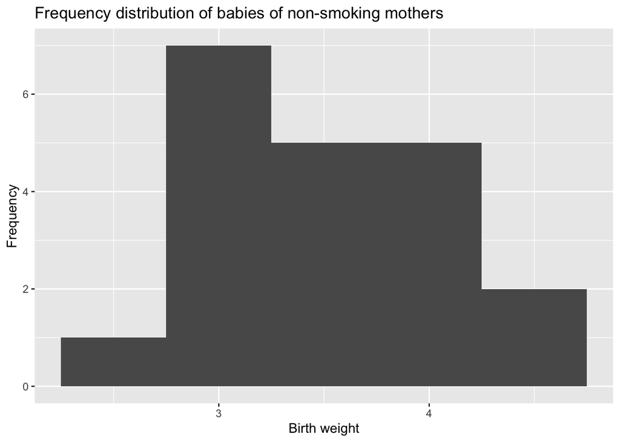

#### 11. Are birthweight data for babies of smoking mothers normally distributed?

Birthweight data for babies of smoking mothers is normally distributed as evideneced by a shapiro test with p value 0.95

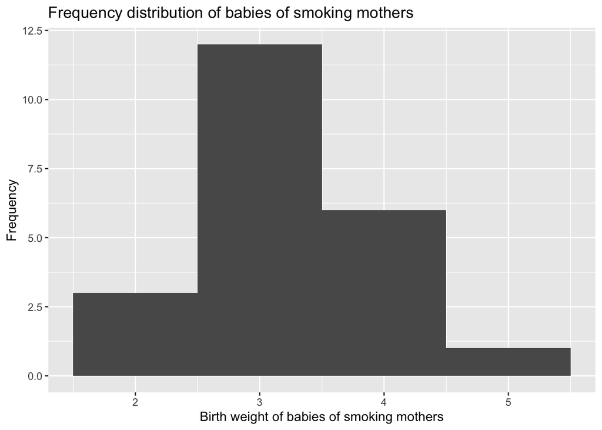